# Predictive Text

Martin Hill

11 August 2017

### Introduction

This is an exploratory look at three source of data (blogs,twitter and news feeds) - raw data provided by SwiftKey (https://d396qusza40orc.cloudfront.net/dsscapstone/dataset/Coursera-SwiftKey.zip). As the title suggests the end goal is to be able predict what word would come next based on previously typed words or phrases. By analysis which words go together and the frequency at which they occur.

I have chosen to include punctuation in as it is also acts as a determiner of what might come next. A collection of letters,words,numbers,punctuation etc seperated by spaces are called terms or more specifically grams: a 1-gram would have 1 items, a 2-gram would have 2 items and so on.

In this report we have focused on the en_US locale, however language based settings amongst others settings are included in the code:

*locale en_US - language based* encoding UTF-8 - character system used for in the source *cache FALSE - use precalculated saved values* Sample_percentage 0.01 - fraction of text files to sample *TopTerms_LowFrequency 10 - mininum number of word/phrases to use in top terms calculations

A profanity filter of 112 words is used currently to remove lines where any are found.

### Exploratory Analysis

A summary of the sources, unsurprisingly shows, that the news have the largest length words, followed by blogs followed by twitter. Blogs use more words per line and twitters the fewest words. Tweets are restricted to 140 characters,

| source | nLines | nWords | nChars | nCharsperWord | nWordsperLine | MaxnChars | MaxnWords |
| --- | --- | --- | --- | --- | --- | --- | --- |
| twitter | 2,360,148 | 30,373,543 | 164,456,178 | 5.41 | 12.87 | 140 | 47 |
| blogs | 899,288 | 37,334,131 | 207,723,792 | 5.56 | 41.52 | 40,833 | 6,630 |
| news | 77,259 | 2,643,969 | 15,716,666 | 5.94 | 34.22 | 5,760 | 1,031 |

### Character Distribution

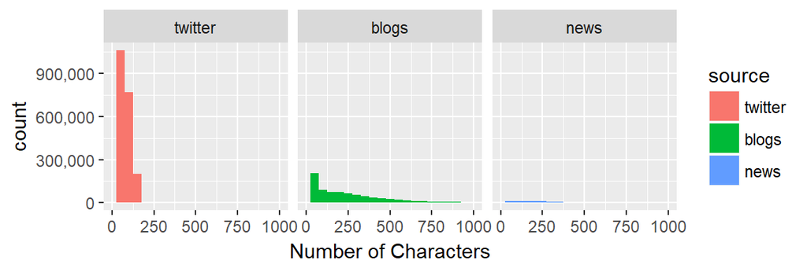

Twitter can seen to be clearly constrained to 140 characters. Whereas news, which has less data, also has a flatter distribution.

### Word Distribution

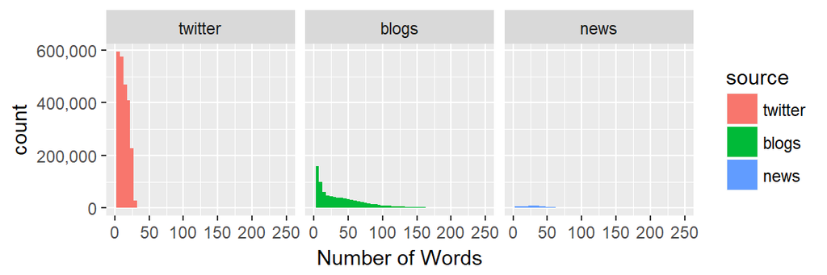

These distributions show that the number of words are constrained for news and particularly for twitter, but not for blogs.Twitter and blogs both show significant use of shorter words. This may be due to the input method predictive keyboard, rather than a standard keyboards used to write news feeds. Unfortunately there is no fields available in the data provided to corroborate this. However, this would provide a useful analysis opportunity in this report i.e. are shorter words used for twitter and blogs.

### Top 10 Frequencies for 1, 2 & 3 N-grams for Blogs as an example.

| 1-N Word | 1-N Freq | 2-N Word | 2-N Freq | 3-N Word | 3-N Freq |
| --- | --- | --- | --- | --- | --- |
| the | 17,711 | of the | 1,759 | . . . | 597 |
| and | 10,631 | , and | 1,680 | , and the | 132 |
| that | 4,630 | . i | 1,546 | , but i | 130 |
| for | 3,372 | in the | 1,488 | . it was | 129 |
| with | 2,811 | . . | 1,119 | a lot of | 123 |
| you | 2,764 | , i | 914 | one of the | 123 |
| was | 2,716 | , but | 910 | , and i | 122 |
| this | 2,495 | to the | 884 | . i was | 114 |
| have | 2,063 | . the | 830 | . i have | 99 |
| but | 1,907 | , the | 799 | . it is | 94 |

### 1-grams Word Clouds for twitter, blogs, news

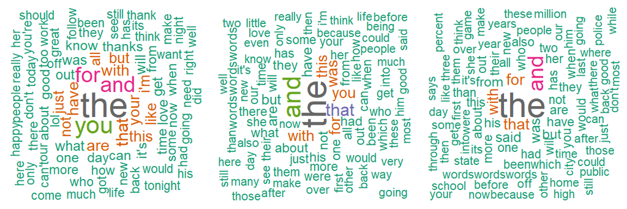

### 2-grams Word Clouds for twitter, blogs, news

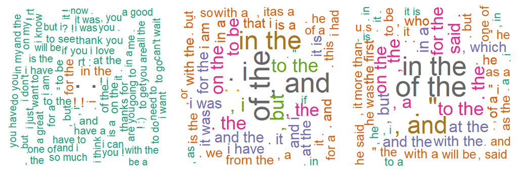

### 3-grams Word Clouds for twitter, blogs, news

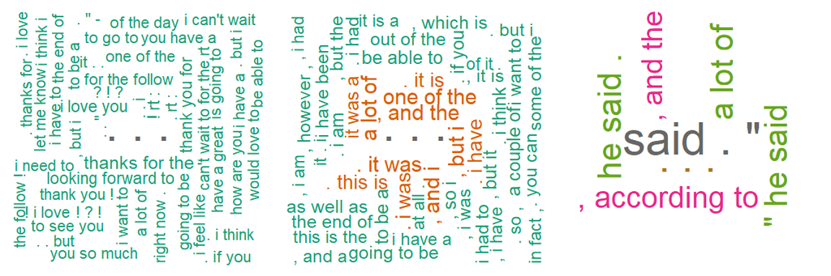

### Futher considerations for an effective App (the Tech bit)

Caching has been used this process to save cleaned files, but memory management and speed could be improved. That and some other considerations are:

*Removing unwanted objects and use a garbage collector to prevent memory loss so can use as large a sample as possible vs the time taken, and so aid prediction.* Consider using stemming to reduce words to there root words - but this may impair prediction, is there a trade-off? *Use Markov Chains as an improvement on the N-grams for prediction of next words.* Use a back off model for unobserved n-grams. *Does punctuation really need including. Then can use the RWeka library which is reputed to be more efficient.* Employ a train/test set methodology.